# Data Analytics - Challenge

The goal of this challenge is to analyze a restaurant invoices. Some celles are already implemented, you just need to **run** them. Some other cells need you to write some code.

Start the challenge by running the two following cells:

```python
import pandas as pd
import seaborn as sns
import matplotlib.pyplot as plt
```

```python
tips_df = pd.read_csv("https://raw.githubusercontent.com/mwaskom/seaborn-data/master/tips.csv")
```

❓ Display the 10 first rows of the dataset (no need to sort)

**🙈 Reveal solution**

You can use the [`pandas.DataFrame.head()`](https://pandas.pydata.org/pandas-docs/stable/reference/api/pandas.DataFrame.head.html) function:

```
tips_df.head(10)
```

```python
tips_df.head(10)
```

|  | total_bill | tip | sex | smoker | day | time | size |
| --- | --- | --- | --- | --- | --- | --- | --- |
| 0 | 16.99 | 1.01 | Female | No | Sun | Dinner | 2 |
| 1 | 10.34 | 1.66 | Male | No | Sun | Dinner | 3 |
| 2 | 21.01 | 3.50 | Male | No | Sun | Dinner | 3 |
| 3 | 23.68 | 3.31 | Male | No | Sun | Dinner | 2 |
| 4 | 24.59 | 3.61 | Female | No | Sun | Dinner | 4 |
| 5 | 25.29 | 4.71 | Male | No | Sun | Dinner | 4 |
| 6 | 8.77 | 2.00 | Male | No | Sun | Dinner | 2 |
| 7 | 26.88 | 3.12 | Male | No | Sun | Dinner | 4 |
| 8 | 15.04 | 1.96 | Male | No | Sun | Dinner | 2 |
| 9 | 14.78 | 3.23 | Male | No | Sun | Dinner | 2 |

❓ How many days per week is the restaurant open?

**🙈 Reveal solution**

You can use the [`pandas.Series.unique()`](https://pandas.pydata.org/pandas-docs/stable/reference/api/pandas.Series.unique.html) function combiend with the `len()` Python built-in.

```
len(tips_df['day'].unique())
```

```python
len(tips_df['day'].unique())
```

```
4
```

❓ What day of the week is there more bills? Plot this with a Seaborn Countplot.

**🙈 Reveal solution**

```
tips_df['day'].value_counts()
```

```
sns.countplot(data=tips_df, x='day', order=['Thur', 'Fri', 'Sat', 'Sun'])
```

```python
tips_df['day'].value_counts()
```

```
Sat     87
Sun     76
Thur    62
Fri     19
Name: day, dtype: int64
```

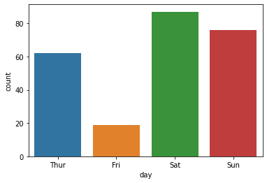

```python
sns.countplot(data=tips_df, x='day', order=['Thur', 'Fri', 'Sat', 'Sun'])
```

❓ Try to do some other countplots, varying `x` with one of the categorical column (`sex`, `smoker`, `time`)

[figure not shown]

```python
sns.countplot(data=tips_df, x='time', order=['Thur', 'Fri', 'Sat', 'Sun'])
```

❓ Let's plot the distribution of `total_bill` based on a given category. Start with `day`:

```
sns.catplot(data=tips_df, x='day', y='total_bill', kind="box")
```

1. Change the value of `x` with one of the categorical column of the dataset and the value of `kind` (`"bar"`, `"box"`, `"violin"`, `"boxen"`)
2. Change the value of `y` with one of the numerical column of the dataset

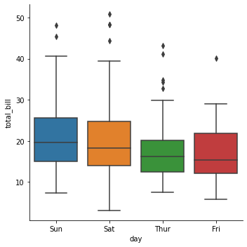

```python
sns.catplot(data=tips_df, x='day', y='total_bill', kind="box")
```

❓ Let's use [`seaborn.FacetGrid`](https://seaborn.pydata.org/generated/seaborn.FacetGrid.html)

1. Run the cell below. What do you observe?
2. Change `col` in the first line with another column (e.g. `"time"`). Run the cell again. What do you observe?

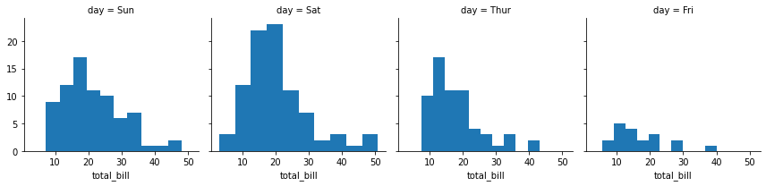

```python
g = sns.FacetGrid(tips_df, col="day")
g.map(plt.hist, "total_bill")
```

❓ Let's continue with FacetGrid and add a `row="smoker"` parameter. How many cells do you get in the plot?

**🙈 Reveal solution**

You get 2 * 4 = 8 cells!

```
g = sns.FacetGrid(tips_df, col="day", row="smoker")
g.map(plt.hist, "total_bill")
```

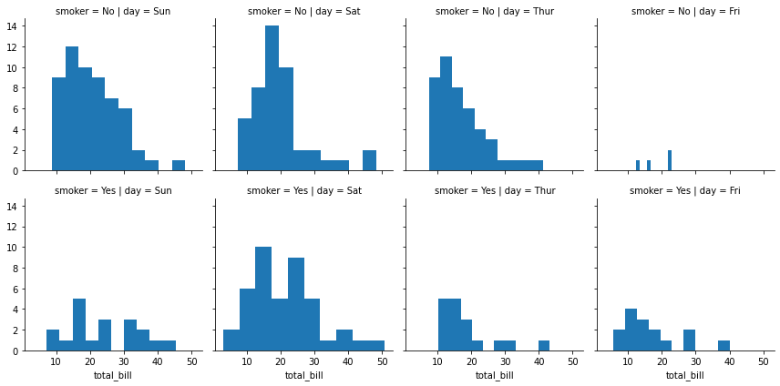

```python
g = sns.FacetGrid(tips_df, col="day", row="smoker")
g.map(plt.hist, "total_bill")
```

## Correlation

Let's start looking for correlation between columns in the dataset.

❓ What is your intuition about the relationship between the columns `tip` and `total_bill`?

❓ Let's look at the data to see if our intuition is correct. We will do a **scatterplot** with `x` being `total_bill` and `y` the tip.

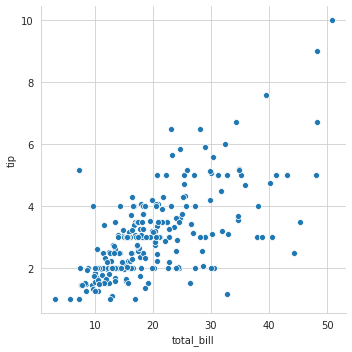

```python
with sns.axes_style(style="whitegrid"):
    sns.relplot(x="total_bill", y="tip", data=tips_df)
```

❓ Another way of looking at this data is to use a [`seaborn.jointplot`](https://seaborn.pydata.org/generated/seaborn.jointplot.html).

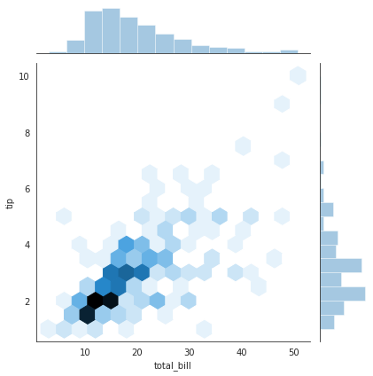

```python
with sns.axes_style("white"):
    sns.jointplot(x="total_bill", y="tip", kind="hex", data=tips_df)
```

❓ A very useful tool to **identify** correlations is the [`seaborn.pairplot`](https://seaborn.pydata.org/generated/seaborn.pairplot.html):

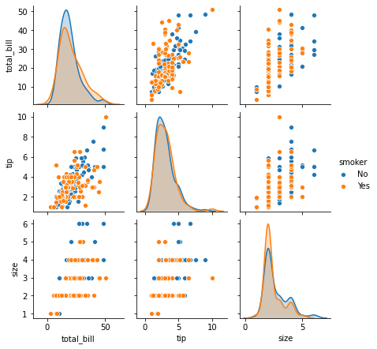

```python
sns.pairplot(tips_df, height=2, hue="smoker")
```

## Regression

We are not doing Machine Learning yet but we can use [`seaborn.lmplot`](https://seaborn.pydata.org/generated/seaborn.lmplot.html) to graphically read a linear correlation between two columns:

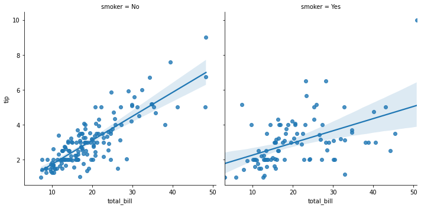

```python
sns.lmplot(x="total_bill", y="tip", col="smoker", data=tips_df)
```

## Good job!

Save your notebook, go back to the **Le Wagon - Learn** platform to upload your progress. A quiz awaits you!